# Reproducible Research Course Project 1

RAUL BARREA

September 9, 2018

# Part 1: Loading and preprocessing the data

This code reads the file containing data from a personal activity monitoring device.

This device collects data at 5 minute intervals through out the day.

The data consists of two months of data from an anonymous individual collected during the months of October and November, 2012 and include the number of steps taken in 5 minute intervals each day.

## load dplyr library

```r
library(dplyr)
```

## set working directory, loads the file, and group data by date

```r
setwd("C:/Users/raul/Documents/Raul_Barrea_Coursera/REproducible Research")
file.url <- "https://d396qusza40orc.cloudfront.net/repdata/data/activity.zip"
download.file(file.url,"activity.zip")
unzip("activity.zip")
activity <- read.csv("activity.csv")
activity.by.date <- activity %>% group_by(date)
```

# What is mean total number of steps taken per day?

Calculate Total number of steps per day, mean and median values ignoring mising values in the sum, mean, and median calculations.

```r
## here I keep the missing values when calculating the sum, otherwise it will replace the sum by zero.
Total.steps.per.day <- activity.by.date %>% summarize(steps = sum(steps))
## here I calculate the mean and median of all total steps without considering the NAs
Mean.steps.total <- mean(Total.steps.per.day$steps,na.rm=TRUE)
Median.steps.total <- median(Total.steps.per.day$steps,na.rm=TRUE)

## Mean total number of steps taken per day
Mean.steps.total
```

```
## [1] 10766.19
```

```r
## Median total number of steps taken per day
Median.steps.total
```

```
## [1] 10765
```

## Plot the histogram of frequency of steps

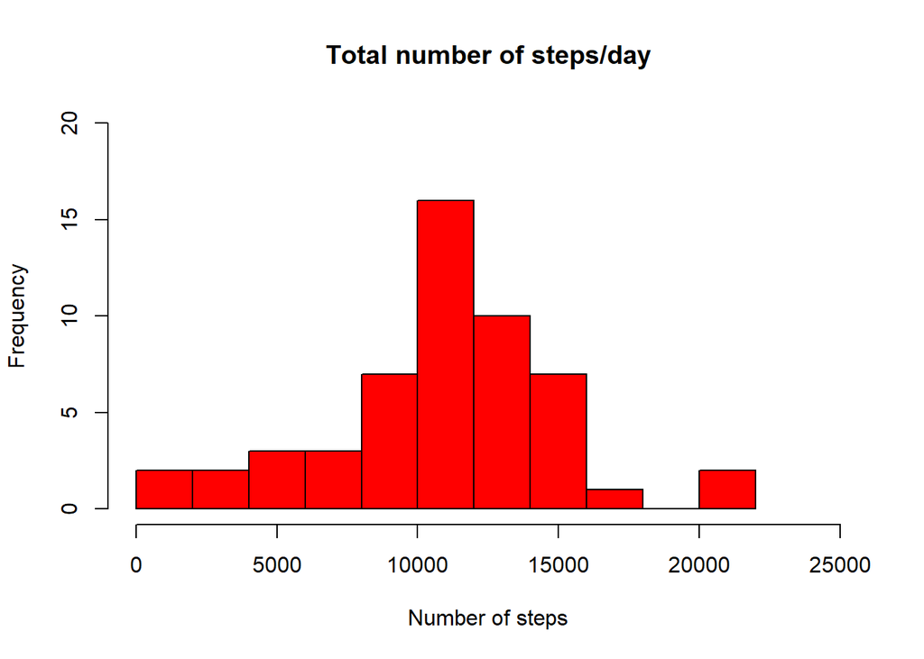

```r
hist(Total.steps.per.day$steps, col= "red", xlab = "Number of steps",main= "Total number of steps/day", ylim = c(0, 20),xlim=c(0,25000),breaks=8)
```

# What is the average daily activity pattern?

Group data by interval, calculate mean steps per interval. ignoring mising values in the calculation

```r
##set interval to a specific format
activity$interval <- sprintf("%04d", activity$interval)

activity.by.interval <- activity %>% group_by(interval)

Mean.steps.per.interval <- activity.by.interval %>% summarize(steps = mean(steps,na.rm=TRUE))

Num.intervals <- seq(from=1,to= length(Mean.steps.per.interval$steps))
```

Plotting Average # of Steps per interval

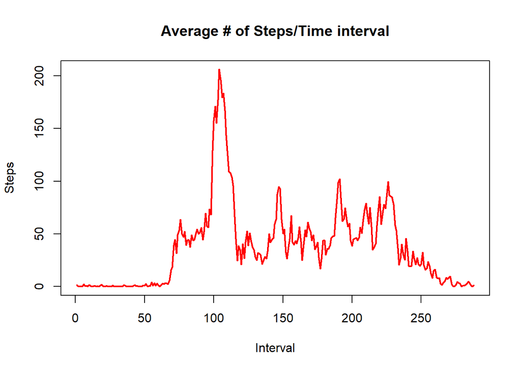

```r
plot(Num.intervals, Mean.steps.per.interval$steps, type= "l", xlab= "Interval", ylab= "Steps",main="Average # of Steps/Time interval", col="red" , lwd=2)
```

Interval with maximum nuber of steps on average

```r
Max.interval <- which(Mean.steps.per.interval$steps==max(Mean.steps.per.interval$steps))
Max.interval
```

```
## [1] 104
```

# Imputing missing values

How many NAs in the data set?

```r
Number.of.NAs <- length(which(is.na(activity$steps)))
Number.of.NAs
```

```
## [1] 2304
```

Replaces NAs using the average steps in a given day

if there is no mean value on a given day, a zero value is assigned

```r
activity.by.date <- activity %>% group_by(date)
##calculate the mean value per day
Mean.steps.per.day <- activity.by.date %>% summarize(meansteps = mean(steps,na.rm=TRUE))
##assigns zero of there is no mean (due to NAs)
Mean.steps.per.day[which(is.na(Mean.steps.per.day[,2])),2] <- 0

New.activity <- merge(activity,Mean.steps.per.day,by="date")
new.vector <- which(is.na(New.activity[,2]))
New.activity[new.vector,2] <- New.activity[new.vector,4]
New.activity.per.day <- New.activity %>% group_by(date)

##Calculate Total number of steps per day, mean and median values
## mising values were replaced by mean value per day.

Total.steps.per.day <- New.activity.per.day %>% summarize(steps = sum(steps))
Mean.steps.total <- mean(Total.steps.per.day$steps)
Median.steps.total <- median(Total.steps.per.day$steps)

## Mean total number of steps taken per day
Mean.steps.total
```

```
## [1] 9354.23
```

```r
## Median total number of steps taken per day
Median.steps.total
```

```
## [1] 10395
```

Plot the histogram of frequency of steps

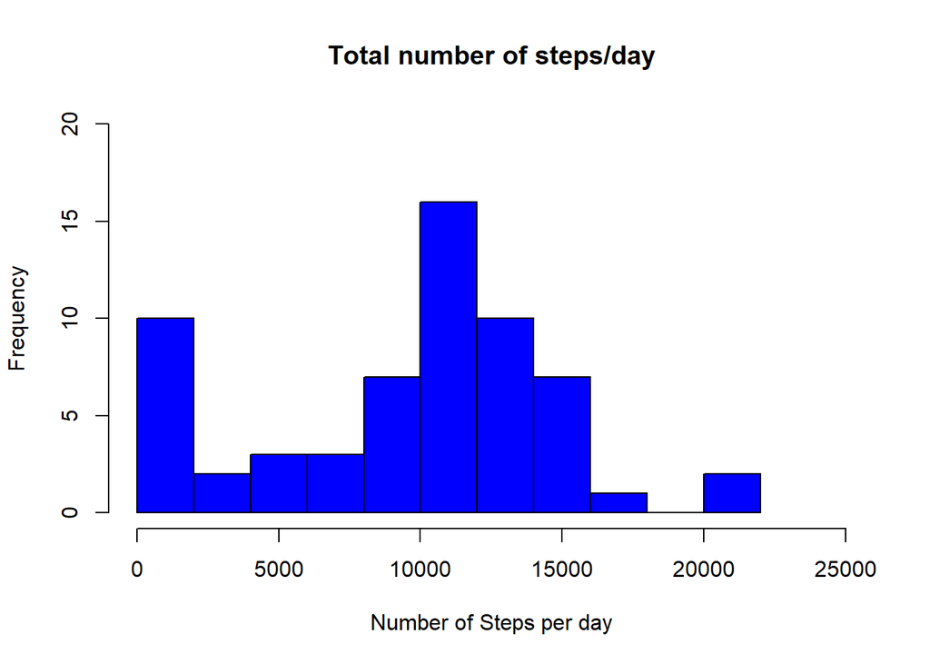

```r
hist(Total.steps.per.day$steps, col= "blue", xlab = "Number of Steps per day",main= "Total number of steps/day", ylim = c(0, 20),xlim=c(0,25000),breaks=8)
```

# Are there differences in activity patterns between weekdays and weekends?

```r
##Set factor: Weekends and weekdays
New.activity.per.day$date <- weekdays(as.Date(New.activity.per.day$date, format = "%Y-%m-%d"))
weekdays1 <- c('Monday', 'Tuesday', 'Wednesday', 'Thursday', 'Friday')

New.activity.per.day$wDay <- factor((New.activity.per.day$date %in% weekdays1), levels=c("FALSE", "TRUE"), labels=c('weekend', 'weekday'))

##Calculate Total number of steps per day, mean and median values
## mising values were replaced by mean value per day.

Total.steps.per.day <- New.activity.per.day %>% summarize(steps = sum(steps))
Mean.steps.total <- mean(Total.steps.per.day$steps)
Median.steps.total <- median(Total.steps.per.day$steps)

activity.per.interval <- New.activity.per.day %>% group_by(wDay, interval)

Mean.steps.per.interval <- activity.per.interval %>% summarize(steps = mean(steps,na.rm=TRUE))

Mean.steps.per.interval.weekend <- Mean.steps.per.interval[which(Mean.steps.per.interval$wDay=="weekend"),]
Mean.steps.per.interval.weekday <- Mean.steps.per.interval[which(Mean.steps.per.interval$wDay=="weekday"),]

## plot the histogram of frequency of steps

Num.steps <- seq(from=1,to = nrow(Mean.steps.per.interval.weekday))
```

plot panel comparing weekends and weekdays

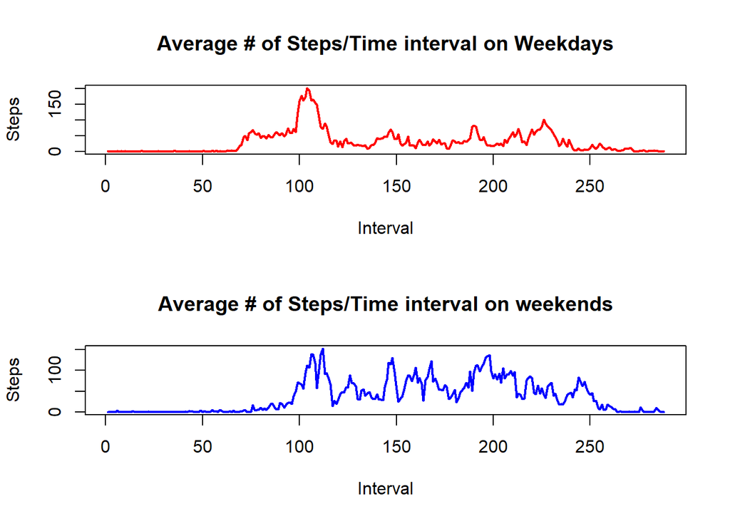

```r
attach(Mean.steps.per.interval.weekday)
par(mfrow=c(2,1))

plot(Num.steps, Mean.steps.per.interval.weekday$steps, type= "l", xlab= "Interval", ylab= "Steps",main="Average # of Steps/Time interval on Weekdays", col="red" , lwd=2)
plot(Num.steps, Mean.steps.per.interval.weekend$steps, type= "l", xlab= "Interval", ylab= "Steps",main="Average # of Steps/Time interval on weekends", col="blue" , lwd=2)
```